# FigureYa2 ggtree+pheatmap+msa

小丫画图出品 2018.4.29

微信ID: epigenomics Email: epigenomics@rainbow-genome.com

### 需求描述

基因家族成员进化树、表达谱聚类、多序列比对，组图

本文档分别绘制三个图，没有组到一张图里

另一份文档解决组图问题（by Y叔） ggtree_pheatmap_msa_cowplot.html

### 使用场景

在嘉因公众号回复“ggtree”查看详情。

场景一：多组sample的RNA-seq数据画完heatmap，发现我感兴趣的基因家族所在的cluster当中，有一些功能未知的基因。这些功能未知基因是否也属于这个基因家族？做多序列比对看看，它们是否具有相似的结构区域。

场景二：我鉴定出来一个新的转录因子，它有什么功能？序列相似预示着功能相似，做多序列比对，先找到序列相似的已知转录因子，再下载公共数据，查看它们的表达谱是否也是一致的。

### 表达谱聚类

给同一group的sample加上同一种颜色，就能看出两个group的sample分别被聚到两类，说明这些基因能够用来区分两个group

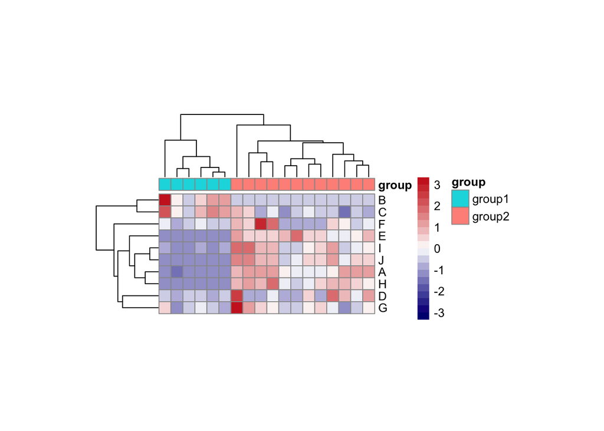

```r
#install.packages("pheatmap")
require(pheatmap)
df<-read.table("easy_input.txt",header = T, row.names = 1,as.is = 1)

annotation_col = data.frame(group = factor(rep(c("group1","group2"),c(6,12))))
rownames(annotation_col) = colnames(df)
ann_colors = list(Stage = c(group1 = "#FFFFCC", group2 = "#FEFF23"))
pheatmap(df,method="spearman", cluster_rows=T, cluster_cols=T,
         cellwidth = 10, cellheight = 10, fontsize = 10,
         color = colorRampPalette(c("navy", "white", "firebrick3"))(20),
         scale="row", show_colnames=F,
         annotation_col = annotation_col,
         annotation_colors = ann_colors)
```

### 多序列比对

msa包需要LaTex，MAC系统推荐安装MacTex

```r
#source("https://bioconductor.org/biocLite.R")
#biocLite("msa")
require(msa)
#输入文件
#借用msa自带的exampleAA.fasta
mySequenceFile <- system.file("examples", "exampleAA.fasta", package="msa")
mySequences <- readAAStringSet(mySequenceFile)
#自己的fasta文件读入方式：
#mySequences <- readAAStringSet("file.fa")

#多序列比对
myFirstAlignment <- msa(mySequences)
```

```
## use default substitution matrix
```

```r
#输出pdf文件
tmpFile<-tempfile(pattern="exampleAA",tmpdir=".",fileext=".pdf")
msaPrettyPrint(myFirstAlignment, file=tmpFile,output="pdf",
                 paperWidth=15, paperHeight=10,
                 showNames="right",showLogo="none", showNumbering="none",
                 showConsensus = "none",
                 askForOverwrite=FALSE, verbose=FALSE)
```

### 进化树

```r
#install.packages(c("seqinr","ape"))
#用多序列比对的结果计算距离
require(seqinr)
myAlignment <- msaConvert(myFirstAlignment, type="seqinr::alignment")
d <- dist.alignment(myAlignment, "identity")

#构建NJ树
require(ape)
tree <- nj(d)

#画树并输出到PDF文件ggtree.pdf
require(ggtree)
```

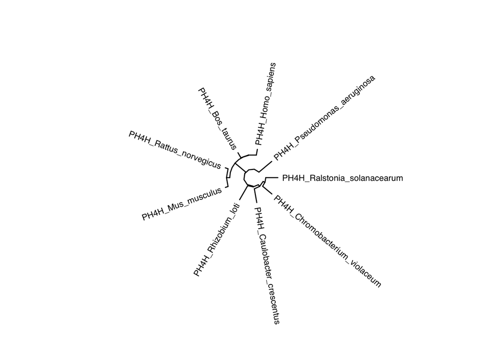

```r
p2 <- ggtree(tree, layout='circular') + geom_tiplab2(size=3, offset=.1) + xlim(-.2, 3)
p2
```

```r
#输出pdf文件
pdf(file="ggtree.pdf")
p2
dev.off()
```